# Canonical correspondence analysis for winter controls on phytoplankton distribution

# 1 Introduction

This document presents a multivariate analysis of the relationships between trace metals and phytoplankton community composition. It provides a brief overview of the statistical methods and interpretation. This is followed by the code and outputs.

# 2 Method overview

The factors influencing the phytoplankton community structure were investigated using a canonical correspondence analysis (CCA). The analysis was conducted in R using the `cca` function from the Vegan package. The biotic variables were represented by the CHEMTAX-derived taxonomic groups’ biomass (µg/L of Chl a). The CCA was repeated for multiple sets of environmental parameters:

- temperature, salinity, macronutrients, trace metals (dissolved and particulate) for all stations that include trace metals.
- Macronutrients for all stations for all stations excluding station I008
- Dissolved trace metals for all stations excluding station I008
- Particulate trace metals for all stations excluding station I008

Permutation tests were run based on 999 permutations to evaluate the significance of the CCA axes and the significance of the environmental variables.The A p-value threshold of 0.05 was used to determine statistical significance.

# 3 CCA analysis

## 3.1 Verifying assumptions: unimodality

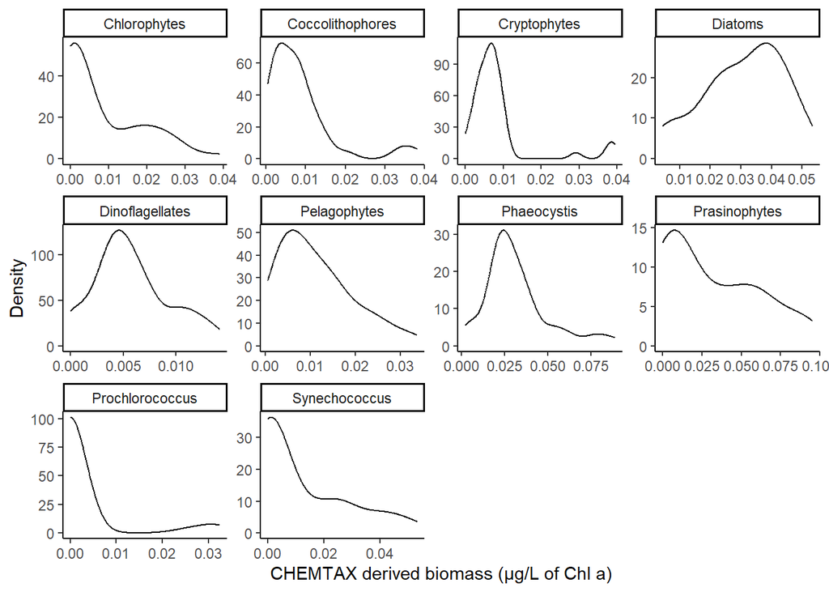

Figure 3.1: Density plots of CHEMTAX derived taxonomical groups’ biomass (µg/L of Chl a)

From the density plots above, the phytoplankton biomass for the various taxonomic groups appear to be unimodal.

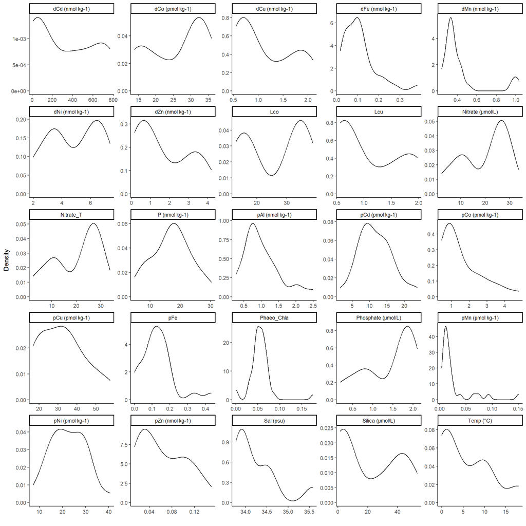

Figure 3.2: Density distribution plots of environmental variables

## 3.2 CCA results

### 3.2.1 Analysis 1: All variables

#### 3.2.1.1 Correlation plots

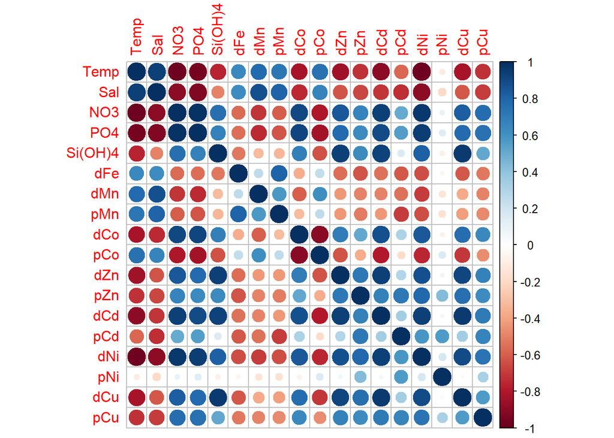

#### 3.2.1.2 CCA outputs

The CCA results are shown below:

Table 3.1: Table 3.2: Partitioning of scaled Chi-square for the CCA

| Partition | Inertia | Proportion |
| --- | --- | --- |
| Total | 0.461 | 1 |
| Constrained | 0.461 | 1 |
| Unconstrained | 0.000 | 0 |

Table 3.3: Table 3.4: The proportion of variation explained by each CCA axis for the CCA Temperature, salinity, macronutrients, trace metals and phaeopigments:Tchla

|  | CCA1 | CCA2 | CCA3 | CCA4 | CCA5 | CCA6 | CCA7 | CCA8 | CCA9 |
| --- | --- | --- | --- | --- | --- | --- | --- | --- | --- |
| Eigenvalue | 0.24 | 0.136 | 0.050 | 0.022 | 0.006 | 0.004 | 0.002 | 0.001 | 0 |
| Proportion Explained | 0.52 | 0.295 | 0.109 | 0.047 | 0.014 | 0.008 | 0.004 | 0.002 | 0 |
| Cumulative Proportion | 0.52 | 0.816 | 0.925 | 0.973 | 0.986 | 0.994 | 0.998 | 1.000 | 1 |

Variance inflation factors were calculated using the `vif.cca` function. Variance inflation is an indicator of redundancy/colinearity of variables. Variance inflation factors greater than 10 generally indicate that the colinearity of the variables is likely to hinder interpretation of the CCA. The user guide states:

“Variance inflation is a diagnostic tool to identify useless constraints. A common rule is that values over 10 indicate redundant constraints. If later constraints are complete linear combinations of conditions or previous constraints, they will be completely removed from the estimation, and no biplot scores or centroids are calculated for these aliased constraint.”

Table 3.5: Table 3.6: Variance Inflation Factors for the CCA with Temperature, salinity, macronutrients, trace metals and phaeopigments:Tchla

|  | x |
| --- | --- |
| Temp | 8292.005 |
| Sal | 116362.396 |
| NO3 | 2798.154 |
| PO4 | 21599.576 |
| `Si(OH)4` | 1293.173 |
| dFe | 155.794 |
| dMn | 6876.291 |
| pMn | 836.179 |
| dCo | 3090.705 |
| pCo | 1028.740 |
| dZn | 256.905 |
| pZn | 278.086 |
| dCd | 13680.415 |
| pCd | 485.400 |
| dNi | 18393.424 |
| pNi | 41.844 |
| dCu | NA |
| pCu | NA |

Table 3.7: Table 3.8: Aliased variables. Row names indicate the variables that aliased (i.e. can be expressed linearly in terms of other terms in the model and values indicate the strength of the relationship. Large values indicate a strong linear relationship and small values a week linear relationship. Aliased variables are removed from the CCA model and not shown.

|  | Temp | Sal | NO3 | PO4 | `Si(OH)4` | dFe | dMn | pMn | dCo | pCo | dZn | pZn | dCd | pCd | dNi | pNi |
| --- | --- | --- | --- | --- | --- | --- | --- | --- | --- | --- | --- | --- | --- | --- | --- | --- |
| dCu | 0.121 | -7.521 | 0.009 | -2.812 | 0.035 | 3.250 | 5.208 | 15.859 | -0.107 | -0.435 | -0.323 | 11.079 | 0.008 | -0.071 | -1.046 | 0.002 |
| pCu | -9.987 | 937.508 | -2.486 | 342.966 | -2.736 | -439.741 | -646.051 | -2064.713 | 14.307 | 52.955 | 40.337 | -1201.498 | -0.868 | 11.033 | 148.114 | -0.577 |

The results of the permutation test to test the significance of the CCA are shown below:

Table 3.9: Table 3.10: Significance of overall CCA for the CCA with Temperature, salinity, macronutrients, trace metals and phaeopigments:Tchla

|  | Df | ChiSquare | F | Pr(>F) |
| --- | --- | --- | --- | --- |
| Model | 16 | 0.461 | NA | NA |
| Residual | 0 | 0.000 | NA | NA |

The significance of the CCA axes are shown below:

Table 3.11: Table 3.12: Significance of CCA axes for the CCA with Temperature, salinity, macronutrients, trace metals and phaeopigments:Tchla

|  | Df | ChiSquare | F | Pr(>F) |
| --- | --- | --- | --- | --- |
| Model | 16 | 0.461 | NA | NA |
| Residual | 0 | 0.000 | NA | NA |

The significance of the terms for the environmental variables:

Table 3.13: Table 3.14: Significance of CCA terms (environmental variables) for the CCA with Temperature, salinity, macronutrients, trace metals and phaeopigments:Tchla

|  | Df | ChiSquare | F | Pr(>F) |
| --- | --- | --- | --- | --- |
| Model | 16 | 0.461 | NA | NA |
| Residual | 0 | 0.000 | NA | NA |

The CCA biplot is shown below:

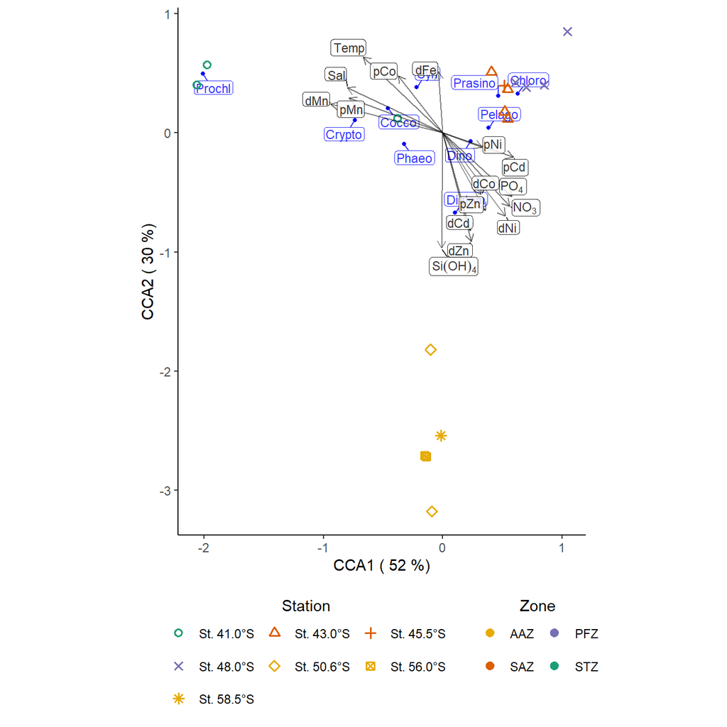

### 3.2.2 Analysis 2: Macronutrients

#### 3.2.2.1 Correlation plots

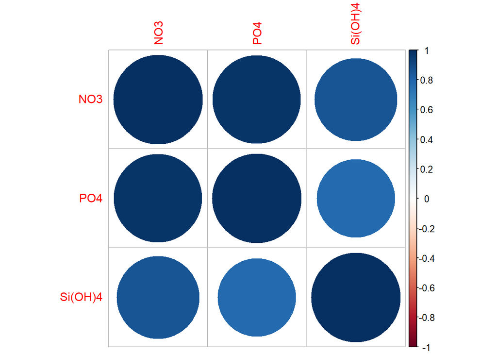

Figure 3.5: Correlation matrix for macronutrients

#### 3.2.2.2 CCA outputs

The CCA results are shown below:

Table 3.1: Table 3.1: Partitioning of scaled Chi-square for the CCA

| Partition | Inertia | Proportion |
| --- | --- | --- |
| Total | 0.299 | 1.000 |
| Constrained | 0.192 | 0.641 |
| Unconstrained | 0.107 | 0.359 |

Table 3.3: Table 3.3: The proportion of variation explained by each CCA axis for the CCA macronutrients

|  | CCA1 | CCA2 | CCA3 | CA1 | CA2 | CA3 | CA4 | CA5 | CA6 | CA7 | CA8 |
| --- | --- | --- | --- | --- | --- | --- | --- | --- | --- | --- | --- |
| Eigenvalue | 0.150 | 0.033 | 0.008 | 0.049 | 0.031 | 0.013 | 0.008 | 0.003 | 0.002 | 0.001 | 0.000 |
| Proportion Explained | 0.503 | 0.111 | 0.027 | 0.165 | 0.103 | 0.044 | 0.025 | 0.010 | 0.006 | 0.003 | 0.002 |
| Cumulative Proportion | 0.503 | 0.614 | 0.641 | 0.806 | 0.909 | 0.953 | 0.979 | 0.989 | 0.995 | 0.998 | 1.000 |

Variance inflation factors were calculated using the `vif.cca` function. Variance inflation is an indicator of redundancy/colinearity of variables. Variance inflation factors greater than 10 generally indicate that the colinearity of the variables is likely to hinder interpretation of the CCA. The user guide states:

“Variance inflation is a diagnostic tool to identify useless constraints. A common rule is that values over 10 indicate redundant constraints. If later constraints are complete linear combinations of conditions or previous constraints, they will be completely removed from the estimation, and no biplot scores or centroids are calculated for these aliased constraint.”

Table 3.5: Table 3.5: Variance Inflation Factors for the CCA with macronutrients

|  | x |
| --- | --- |
| NO3 | 54.348 |
| PO4 | 37.498 |
| `Si(OH)4` | 5.229 |

The results of the permutation test to test the significance of the CCA are shown below:

Table 3.15: Table 3.16: Significance of overall CCA for the CCA with macronutrients

|  | Df | ChiSquare | F | Pr(>F) |
| --- | --- | --- | --- | --- |
| Model | 3 | 0.192 | 21.418 | 0.001 |
| Residual | 36 | 0.107 | NA | NA |

The significance of the CCA axes are shown below:

Table 3.17: Table 3.18: Significance of CCA axes for the CCA with macronutrients

|  | Df | ChiSquare | F | Pr(>F) |
| --- | --- | --- | --- | --- |
| CCA1 | 1 | 0.150 | 50.434 | 0.001 |
| CCA2 | 1 | 0.033 | 11.153 | 0.001 |
| CCA3 | 1 | 0.008 | 2.666 | 0.621 |
| Residual | 36 | 0.107 | NA | NA |

The significance of the terms for the environmental variables:

Table 3.19: Table 3.20: Significance of CCA terms (environmental variables) for the CCA with macronutrients

|  | Df | ChiSquare | F | Pr(>F) |
| --- | --- | --- | --- | --- |
| NO3 | 1 | 0.130 | 43.449 | 0.001 |
| PO4 | 1 | 0.031 | 10.485 | 0.001 |
| `Si(OH)4` | 1 | 0.031 | 10.321 | 0.001 |
| Residual | 36 | 0.107 | NA | NA |

The CCA biplot is shown below:

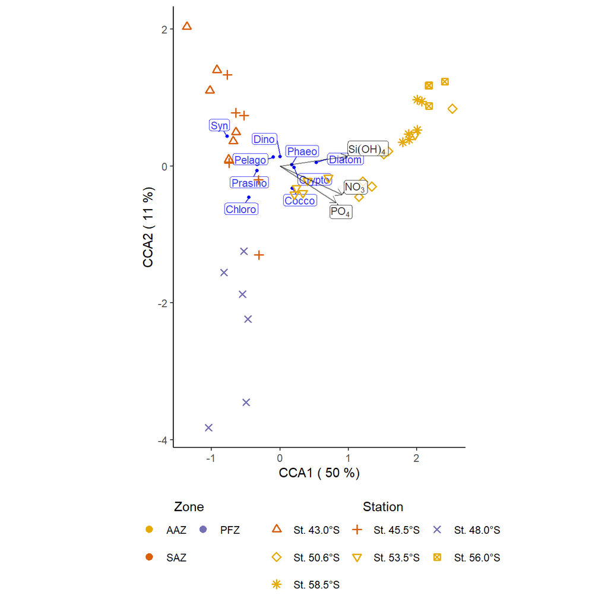

Figure 3.6: Canonical correspondence analysis ordination diagram of absolute contributions of different phytoplankton groups for a CCA with macronutrients. Arrows indicate environment variables: NO3, PO4, and Si(OH)4 . Blue text refer to absolute contributions of phytoplankton groups. Stations are represented by shapes as per the legend and are colored according to the frontal zones in which they are located.

### 3.2.3 Analysis 3: Macronutrients with STZ station

#### 3.2.3.1 Correlation plots

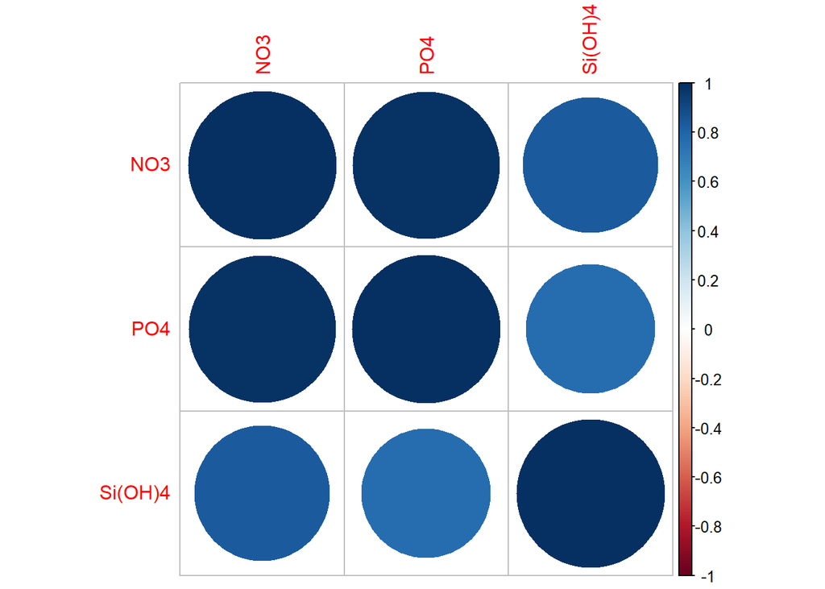

Figure 3.7: Correlation matrix for macronutrients with STZ

#### 3.2.3.2 CCA outputs

The CCA results are shown below:

Table 3.1: Table 3.1: Partitioning of scaled Chi-square for the CCA

| Partition | Inertia | Proportion |
| --- | --- | --- |
| Total | 0.476 | 1.000 |
| Constrained | 0.262 | 0.551 |
| Unconstrained | 0.213 | 0.449 |

Table 3.3: Table 3.3: The proportion of variation explained by each CCA axis for the CCA macronutrients with STZ

|  | CCA1 | CCA2 | CCA3 | CA1 | CA2 | CA3 | CA4 | CA5 | CA6 | CA7 | CA8 | CA9 |
| --- | --- | --- | --- | --- | --- | --- | --- | --- | --- | --- | --- | --- |
| Eigenvalue | 0.143 | 0.112 | 0.007 | 0.112 | 0.045 | 0.030 | 0.010 | 0.007 | 0.005 | 0.003 | 0.001 | 0.000 |
| Proportion Explained | 0.300 | 0.236 | 0.016 | 0.235 | 0.095 | 0.063 | 0.021 | 0.015 | 0.011 | 0.005 | 0.003 | 0.001 |
| Cumulative Proportion | 0.300 | 0.536 | 0.551 | 0.786 | 0.881 | 0.944 | 0.966 | 0.980 | 0.991 | 0.996 | 0.999 | 1.000 |

Variance inflation factors were calculated using the `vif.cca` function. Variance inflation is an indicator of redundancy/colinearity of variables. Variance inflation factors greater than 10 generally indicate that the colinearity of the variables is likely to hinder interpretation of the CCA. The user guide states:

“Variance inflation is a diagnostic tool to identify useless constraints. A common rule is that values over 10 indicate redundant constraints. If later constraints are complete linear combinations of conditions or previous constraints, they will be completely removed from the estimation, and no biplot scores or centroids are calculated for these aliased constraint.”

Table 3.5: Table 3.5: Variance Inflation Factors for the CCA with macronutrients with STZ

|  | x |
| --- | --- |
| NO3 | 81.667 |
| PO4 | 62.936 |
| `Si(OH)4` | 4.489 |

The results of the permutation test to test the significance of the CCA are shown below:

Table 3.15: Table 3.15: Significance of overall CCA for the CCA with macronutrients with STZ

|  | Df | ChiSquare | F | Pr(>F) |
| --- | --- | --- | --- | --- |
| Model | 3 | 0.262 | 16.805 | 0.001 |
| Residual | 41 | 0.213 | NA | NA |

The significance of the CCA axes are shown below:

Table 3.17: Table 3.17: Significance of CCA axes for the CCA with macronutrients with STZ

|  | Df | ChiSquare | F | Pr(>F) |
| --- | --- | --- | --- | --- |
| CCA1 | 1 | 0.143 | 27.418 | 0.001 |
| CCA2 | 1 | 0.112 | 21.567 | 0.002 |
| CCA3 | 1 | 0.007 | 1.429 | 0.955 |
| Residual | 41 | 0.213 | NA | NA |

The significance of the terms for the environmental variables:

Table 3.19: Table 3.19: Significance of CCA terms (environmental variables) for the CCA with macronutrients with STZ

|  | Df | ChiSquare | F | Pr(>F) |
| --- | --- | --- | --- | --- |
| NO3 | 1 | 0.142 | 27.280 | 0.001 |
| PO4 | 1 | 0.055 | 10.476 | 0.001 |
| `Si(OH)4` | 1 | 0.066 | 12.659 | 0.001 |
| Residual | 41 | 0.213 | NA | NA |

The CCA biplot is shown below:

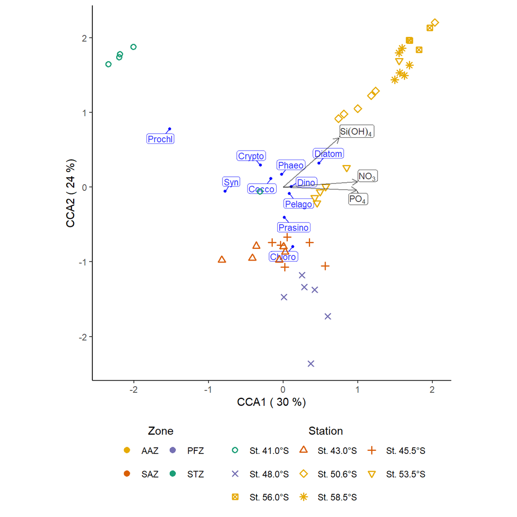

Figure 3.8: Canonical correspondence analysis ordination diagram of absolute contributions of different phytoplankton groups for a CCA with macronutrients with STZ. Arrows indicate environment variables: NO3, PO4, and Si(OH)4 . Blue text refer to absolute contributions of phytoplankton groups. Stations are represented by shapes as per the legend and are colored according to the frontal zones in which they are located.

### 3.2.4 Analysis 4a: Macronutrients and Trace Metals

#### 3.2.4.1 Correlation plots

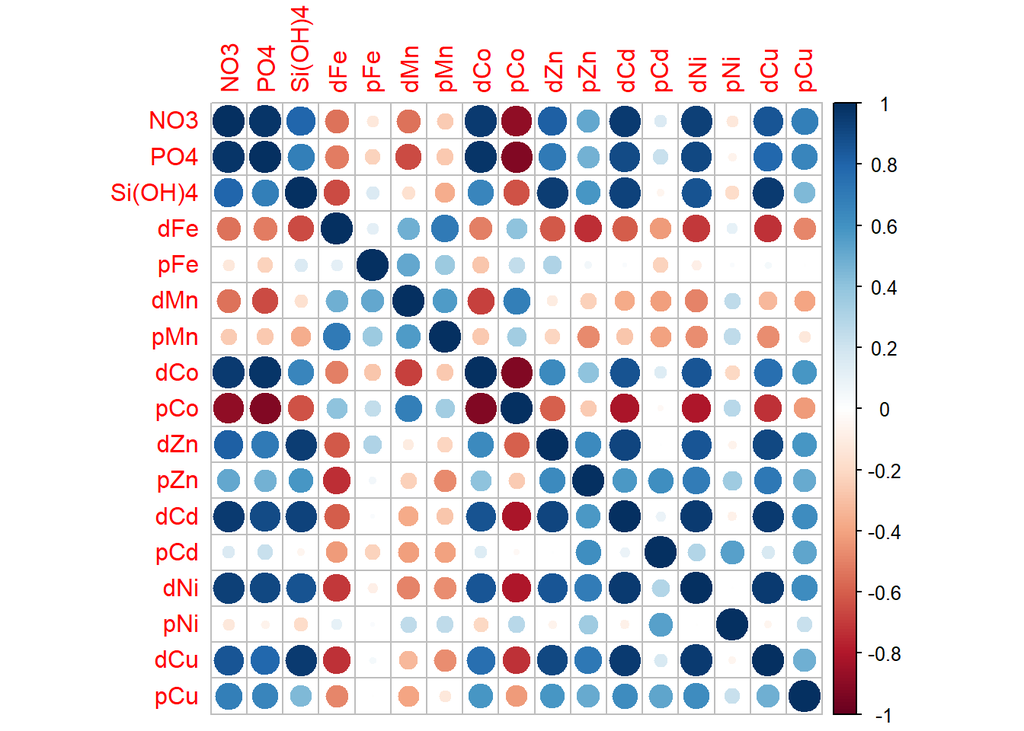

Figure 3.9: Correlation matrix for macronutrients and trace metals

#### 3.2.4.2 CCA outputs

The CCA results are shown below:

Table 3.1: Table 3.1: Partitioning of scaled Chi-square for the CCA

| Partition | Inertia | Proportion |
| --- | --- | --- |
| Total | 0.251 | 1 |
| Constrained | 0.251 | 1 |
| Unconstrained | 0.000 | 0 |

Table 3.3: Table 3.3: The proportion of variation explained by each CCA axis for the CCA macronutrients and trace metals

|  | CCA1 | CCA2 | CCA3 | CCA4 | CCA5 | CCA6 | CCA7 | CCA8 |
| --- | --- | --- | --- | --- | --- | --- | --- | --- |
| Eigenvalue | 0.159 | 0.061 | 0.024 | 0.004 | 0.002 | 0.001 | 0.000 | 0.000 |
| Proportion Explained | 0.633 | 0.241 | 0.097 | 0.014 | 0.009 | 0.004 | 0.001 | 0.001 |
| Cumulative Proportion | 0.633 | 0.874 | 0.970 | 0.985 | 0.994 | 0.998 | 0.999 | 1.000 |

Variance inflation factors were calculated using the `vif.cca` function. Variance inflation is an indicator of redundancy/colinearity of variables. Variance inflation factors greater than 10 generally indicate that the colinearity of the variables is likely to hinder interpretation of the CCA. The user guide states:

“Variance inflation is a diagnostic tool to identify useless constraints. A common rule is that values over 10 indicate redundant constraints. If later constraints are complete linear combinations of conditions or previous constraints, they will be completely removed from the estimation, and no biplot scores or centroids are calculated for these aliased constraint.”

Table 3.5: Table 3.5: Variance Inflation Factors for the CCA with macronutrients and trace metals

|  | x |
| --- | --- |
| NO3 | 1536.432 |
| PO4 | 780.317 |
| `Si(OH)4` | 110.649 |
| dFe | 52.114 |
| pFe | 6.888 |
| dMn | 36.936 |
| pMn | 16.062 |
| dCo | 311.507 |
| pCo | 211.044 |
| dZn | 130.236 |
| pZn | 32.174 |
| dCd | 460.564 |
| pCd | 13.102 |
| dNi | NA |
| pNi | NA |
| dCu | NA |
| pCu | NA |

Table 3.21: Table 3.22: Aliased variables. Row names indicate the variables that aliased (i.e. can be expressed linearly in terms of other terms in the model and values indicate the strength of the relationship. Large values indicate a strong linear relationship and small values a week linear relationship. Aliased variables are removed from the CCA model and not shown.

|  | NO3 | PO4 | `Si(OH)4` | dFe | pFe | dMn | pMn | dCo | pCo | dZn | pZn | dCd | pCd |
| --- | --- | --- | --- | --- | --- | --- | --- | --- | --- | --- | --- | --- | --- |
| dNi | -0.104 | 1.110 | -0.066 | 1.266 | 1.308 | 4.685 | -83.105 | 0.050 | 0.440 | -0.066 | 4.480 | 0.010 | -0.028 |
| pNi | 3.929 | -61.029 | -1.527 | -120.511 | -21.894 | 26.605 | 889.427 | -3.486 | -20.203 | -13.072 | 342.766 | 0.147 | -0.108 |
| dCu | -0.104 | 1.337 | 0.015 | 1.090 | 0.787 | 1.940 | -24.045 | 0.036 | 0.248 | -0.071 | 2.031 | 0.001 | -0.009 |
| pCu | 9.923 | -157.804 | -1.448 | -132.193 | -63.857 | -164.850 | 1625.876 | -3.051 | -24.237 | 6.674 | -32.444 | 0.082 | 2.469 |

The results of the permutation test to test the significance of the CCA are shown below:

Table 3.15: Table 3.15: Significance of overall CCA for the CCA with macronutrients and trace metals

|  | Df | ChiSquare | F | Pr(>F) |
| --- | --- | --- | --- | --- |
| Model | 13 | 0.251 | NA | NA |
| Residual | 0 | 0.000 | NA | NA |

The significance of the CCA axes are shown below:

Table 3.17: Table 3.17: Significance of CCA axes for the CCA with macronutrients and trace metals

|  | Df | ChiSquare | F | Pr(>F) |
| --- | --- | --- | --- | --- |
| Model | 13 | 0.251 | NA | NA |
| Residual | 0 | 0.000 | NA | NA |

The significance of the terms for the environmental variables:

Table 3.19: Table 3.19: Significance of CCA terms (environmental variables) for the CCA with macronutrients and trace metals

|  | Df | ChiSquare | F | Pr(>F) |
| --- | --- | --- | --- | --- |
| Model | 13 | 0.251 | NA | NA |
| Residual | 0 | 0.000 | NA | NA |

The CCA biplot is shown below:

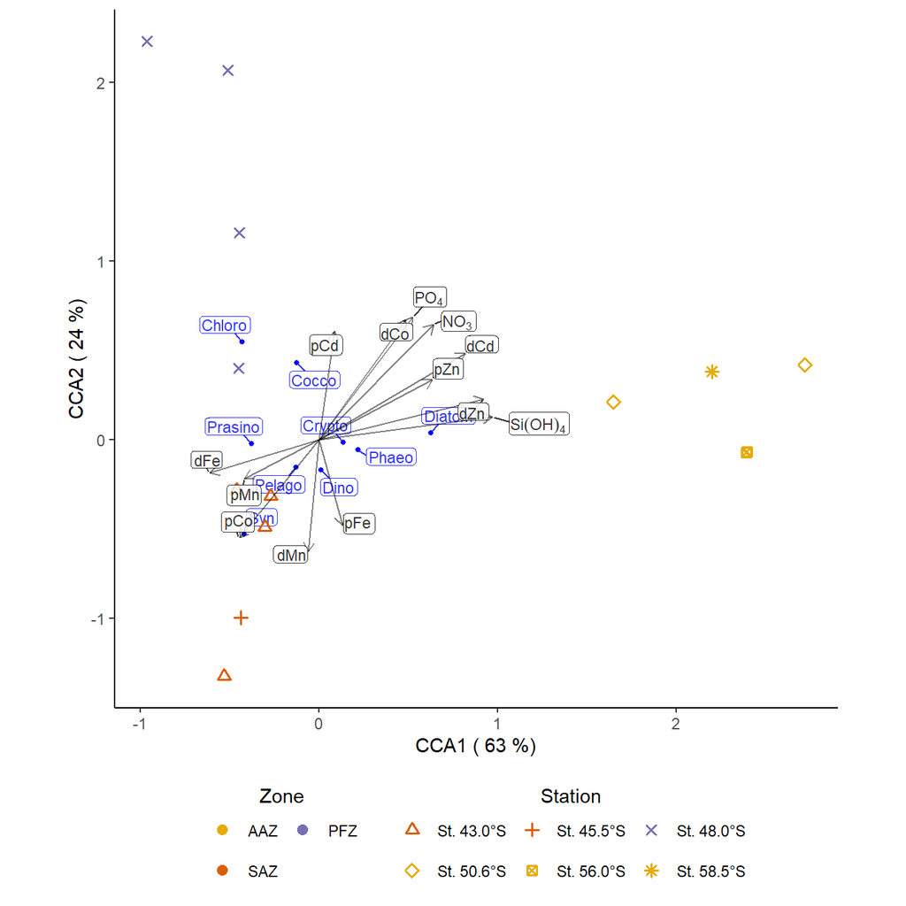

Figure 3.10: Canonical correspondence analysis ordination diagram of absolute contributions of different phytoplankton groups for a CCA with macronutrients and trace metals. Arrows indicate environment variables: NO3, PO4, Si(OH)4, dFe, pFe, dMn, pMn, dCo, pCo, dZn, pZn, dCd, pCd, dNi, pNi, dCu, and pCu . Blue text refer to absolute contributions of phytoplankton groups. Stations are represented by shapes as per the legend and are colored according to the frontal zones in which they are located.

### 3.2.5 Analysis 4b: Macronutrients and Trace Metals with STZ Station

#### 3.2.5.1 Correlation plots

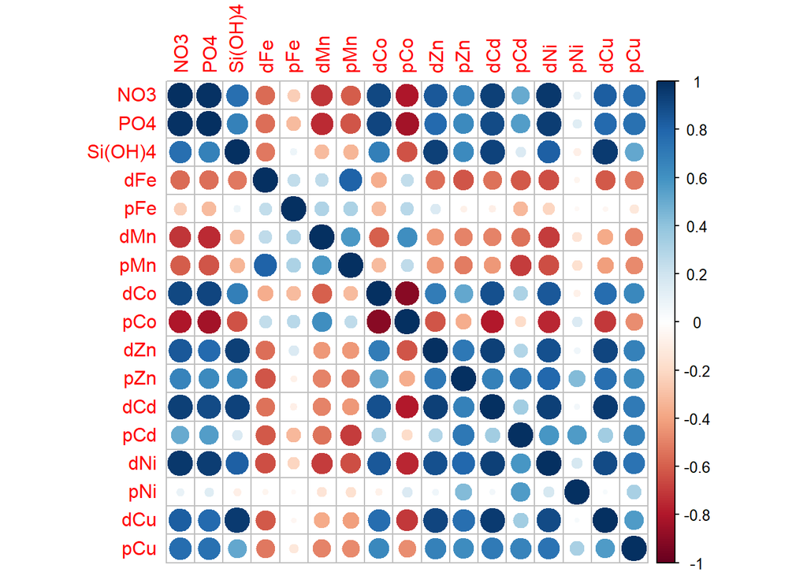

Figure 3.11: Correlation matrix for macronutrients and trace metals with STZ

#### 3.2.5.2 CCA outputs

The CCA results are shown below:

Table 3.1: Table 3.1: Partitioning of scaled Chi-square for the CCA

| Partition | Inertia | Proportion |
| --- | --- | --- |
| Total | 0.461 | 1 |
| Constrained | 0.461 | 1 |
| Unconstrained | 0.000 | 0 |

Table 3.3: Table 3.3: The proportion of variation explained by each CCA axis for the CCA macronutrients and trace metals with STZ

|  | CCA1 | CCA2 | CCA3 | CCA4 | CCA5 | CCA6 | CCA7 | CCA8 | CCA9 |
| --- | --- | --- | --- | --- | --- | --- | --- | --- | --- |
| Eigenvalue | 0.24 | 0.136 | 0.050 | 0.022 | 0.006 | 0.004 | 0.002 | 0.001 | 0 |
| Proportion Explained | 0.52 | 0.295 | 0.109 | 0.047 | 0.014 | 0.008 | 0.004 | 0.002 | 0 |
| Cumulative Proportion | 0.52 | 0.816 | 0.925 | 0.973 | 0.986 | 0.994 | 0.998 | 1.000 | 1 |

Variance inflation factors were calculated using the `vif.cca` function. Variance inflation is an indicator of redundancy/colinearity of variables. Variance inflation factors greater than 10 generally indicate that the colinearity of the variables is likely to hinder interpretation of the CCA. The user guide states:

“Variance inflation is a diagnostic tool to identify useless constraints. A common rule is that values over 10 indicate redundant constraints. If later constraints are complete linear combinations of conditions or previous constraints, they will be completely removed from the estimation, and no biplot scores or centroids are calculated for these aliased constraint.”

Table 3.5: Table 3.5: Variance Inflation Factors for the CCA with macronutrients and trace metals with STZ

|  | x |
| --- | --- |
| NO3 | 1800.935 |
| PO4 | 732.659 |
| `Si(OH)4` | 527.829 |
| dFe | 27.961 |
| pFe | 10.564 |
| dMn | 112.235 |
| pMn | 110.654 |
| dCo | 140.570 |
| pCo | 22.918 |
| dZn | 236.915 |
| pZn | 166.653 |
| dCd | 2383.803 |
| pCd | 25.154 |
| dNi | 902.724 |
| pNi | 25.407 |
| dCu | 971.916 |
| pCu | NA |

Table 3.21: Table 3.21: Aliased variables. Row names indicate the variables that aliased (i.e. can be expressed linearly in terms of other terms in the model and values indicate the strength of the relationship. Large values indicate a strong linear relationship and small values a week linear relationship. Aliased variables are removed from the CCA model and not shown.

|  | NO3 | PO4 | `Si(OH)4` | dFe | pFe | dMn | pMn | dCo | pCo | dZn | pZn | dCd | pCd | dNi | pNi | dCu |
| --- | --- | --- | --- | --- | --- | --- | --- | --- | --- | --- | --- | --- | --- | --- | --- | --- |
| pCu | -2.857 | 5.697 | 1.9 | -47.174 | 23.723 | 59.124 | 153.148 | -0.106 | -4.699 | -10.878 | 387.579 | 0.171 | 1.526 | 25.071 | -0.555 | -168.429 |

The results of the permutation test to test the significance of the CCA are shown below:

Table 3.15: Table 3.15: Significance of overall CCA for the CCA with macronutrients and trace metals with STZ

|  | Df | ChiSquare | F | Pr(>F) |
| --- | --- | --- | --- | --- |
| Model | 16 | 0.461 | NA | NA |
| Residual | 0 | 0.000 | NA | NA |

The significance of the CCA axes are shown below:

Table 3.17: Table 3.17: Significance of CCA axes for the CCA with macronutrients and trace metals with STZ

|  | Df | ChiSquare | F | Pr(>F) |
| --- | --- | --- | --- | --- |
| Model | 16 | 0.461 | NA | NA |
| Residual | 0 | 0.000 | NA | NA |

The significance of the terms for the environmental variables:

Table 3.19: Table 3.19: Significance of CCA terms (environmental variables) for the CCA with macronutrients and trace metals with STZ

|  | Df | ChiSquare | F | Pr(>F) |
| --- | --- | --- | --- | --- |
| Model | 16 | 0.461 | NA | NA |
| Residual | 0 | 0.000 | NA | NA |

The CCA biplot is shown below:

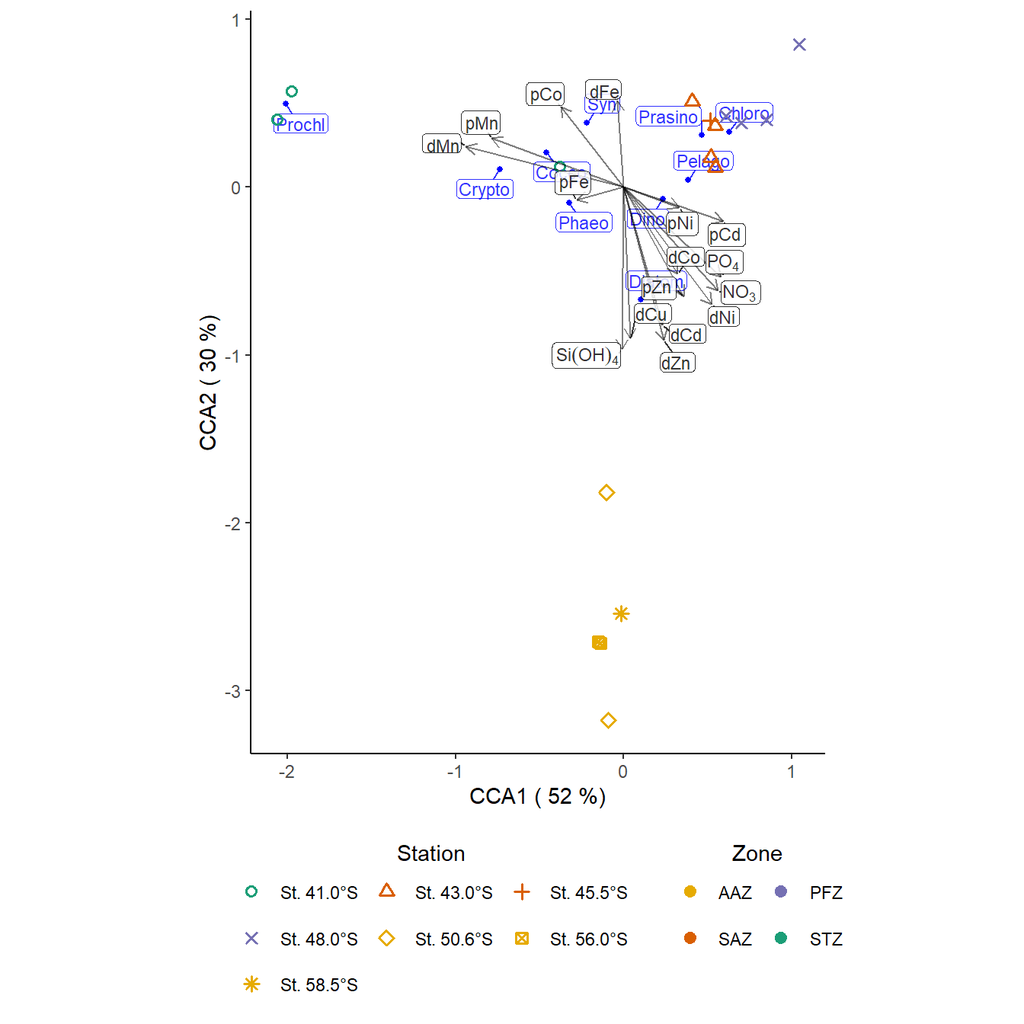

Figure 3.12: Canonical correspondence analysis ordination diagram of absolute contributions of different phytoplankton groups for a CCA with macronutrients and trace metals with STZ. Arrows indicate environment variables: NO3, PO4, Si(OH)4, dFe, pFe, dMn, pMn, dCo, pCo, dZn, pZn, dCd, pCd, dNi, pNi, dCu, and pCu . Blue text refer to absolute contributions of phytoplankton groups. Stations are represented by shapes as per the legend and are colored according to the frontal zones in which they are located.

### 3.2.6 Analysis 5: Dissolved trace metals

#### 3.2.6.1 Correlation plots

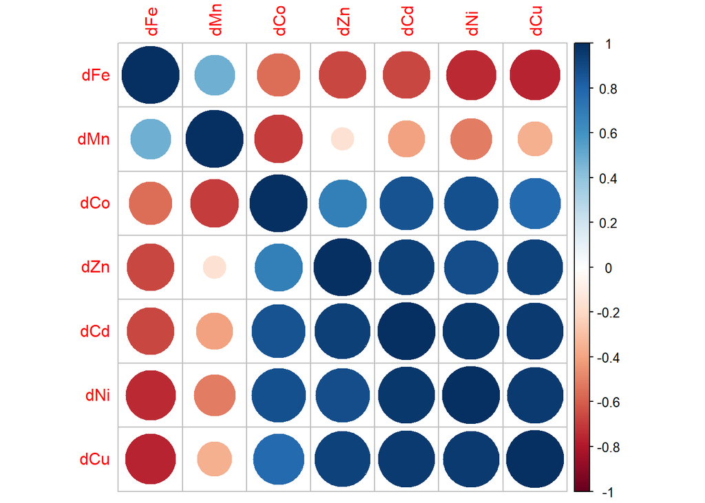

(#fig:cordissolved trace metals)Correlation matrix for dissolved trace metals

#### 3.2.6.2 CCA outputs

The CCA results are shown below:

Table 3.1: Table 3.1: Partitioning of scaled Chi-square for the CCA

| Partition | Inertia | Proportion |
| --- | --- | --- |
| Total | 0.277 | 1.000 |
| Constrained | 0.233 | 0.842 |
| Unconstrained | 0.044 | 0.158 |

Table 3.3: Table 3.3: The proportion of variation explained by each CCA axis for the CCA dissolved trace metals

|  | CCA1 | CCA2 | CCA3 | CCA4 | CCA5 | CCA6 | CCA7 | CA1 | CA2 | CA3 | CA4 | CA5 | CA6 | CA7 | CA8 |
| --- | --- | --- | --- | --- | --- | --- | --- | --- | --- | --- | --- | --- | --- | --- | --- |
| Eigenvalue | 0.172 | 0.043 | 0.014 | 0.003 | 0.001 | 0.000 | 0.000 | 0.022 | 0.010 | 0.009 | 0.002 | 0.001 | 0.000 | 0.000 | 0 |
| Proportion Explained | 0.622 | 0.156 | 0.050 | 0.010 | 0.003 | 0.001 | 0.000 | 0.078 | 0.035 | 0.031 | 0.007 | 0.004 | 0.001 | 0.001 | 0 |
| Cumulative Proportion | 0.622 | 0.778 | 0.828 | 0.838 | 0.841 | 0.842 | 0.842 | 0.920 | 0.956 | 0.987 | 0.994 | 0.998 | 0.999 | 1.000 | 1 |

Variance inflation factors were calculated using the `vif.cca` function. Variance inflation is an indicator of redundancy/colinearity of variables. Variance inflation factors greater than 10 generally indicate that the colinearity of the variables is likely to hinder interpretation of the CCA. The user guide states:

“Variance inflation is a diagnostic tool to identify useless constraints. A common rule is that values over 10 indicate redundant constraints. If later constraints are complete linear combinations of conditions or previous constraints, they will be completely removed from the estimation, and no biplot scores or centroids are calculated for these aliased constraint.”

Table 3.5: Table 3.5: Variance Inflation Factors for the CCA with dissolved trace metals

|  | x |
| --- | --- |
| dFe | 4.524 |
| dMn | 9.753 |
| dCo | 24.541 |
| dZn | 19.140 |
| dCd | 99.739 |
| dNi | 31.947 |
| dCu | 43.699 |

The results of the permutation test to test the significance of the CCA are shown below:

Table 3.15: Table 3.15: Significance of overall CCA for the CCA with dissolved trace metals

|  | Df | ChiSquare | F | Pr(>F) |
| --- | --- | --- | --- | --- |
| Model | 7 | 0.233 | 10.677 | 0.001 |
| Residual | 14 | 0.044 | NA | NA |

The significance of the CCA axes are shown below:

Table 3.17: Table 3.17: Significance of CCA axes for the CCA with dissolved trace metals

|  | Df | ChiSquare | F | Pr(>F) |
| --- | --- | --- | --- | --- |
| CCA1 | 1 | 0.172 | 55.222 | 0.001 |
| CCA2 | 1 | 0.043 | 13.829 | 0.011 |
| CCA3 | 1 | 0.014 | 4.424 | 0.650 |
| CCA4 | 1 | 0.003 | 0.880 | 1.000 |
| CCA5 | 1 | 0.001 | 0.272 | NA |
| CCA6 | 1 | 0.000 | 0.088 | NA |
| CCA7 | 1 | 0.000 | 0.022 | NA |
| Residual | 14 | 0.044 | NA | NA |

The significance of the terms for the environmental variables:

Table 3.19: Table 3.19: Significance of CCA terms (environmental variables) for the CCA with dissolved trace metals

|  | Df | ChiSquare | F | Pr(>F) |
| --- | --- | --- | --- | --- |
| dFe | 1 | 0.094 | 30.155 | 0.001 |
| dMn | 1 | 0.039 | 12.404 | 0.001 |
| dCo | 1 | 0.059 | 19.032 | 0.001 |
| dZn | 1 | 0.018 | 5.667 | 0.005 |
| dCd | 1 | 0.005 | 1.475 | 0.219 |
| dNi | 1 | 0.007 | 2.329 | 0.082 |
| dCu | 1 | 0.011 | 3.674 | 0.036 |
| Residual | 14 | 0.044 | NA | NA |

The CCA biplot is shown below:

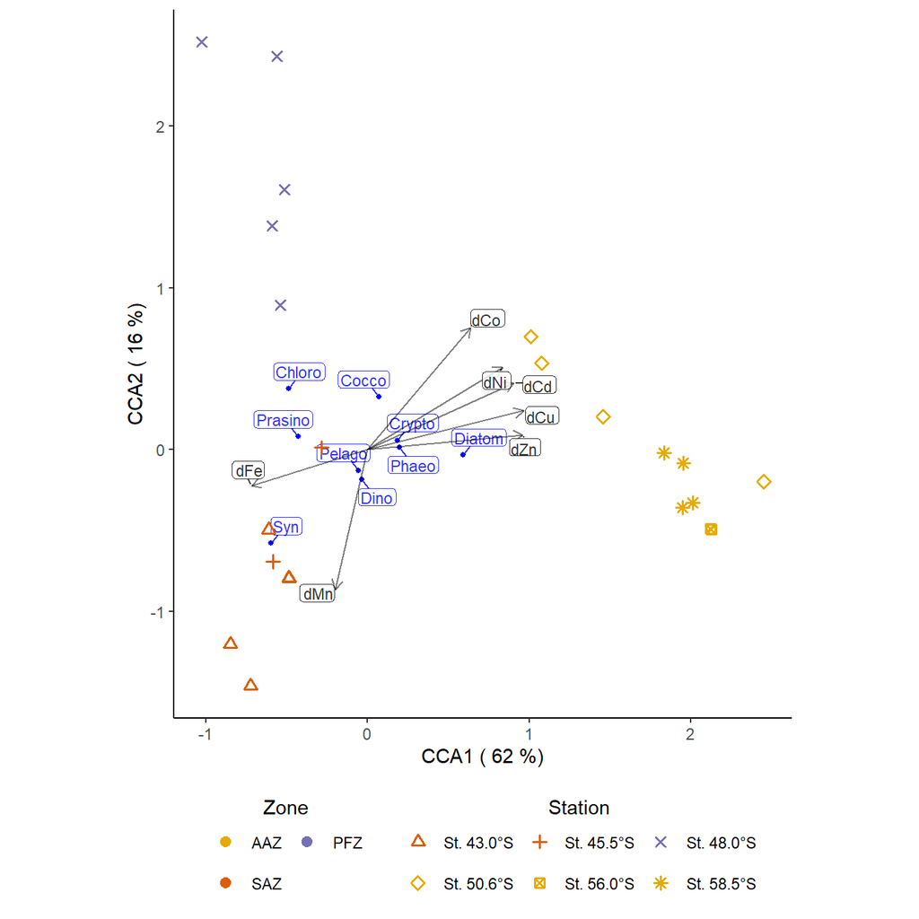

(#fig:dissolved trace metals)Canonical correspondence analysis ordination diagram of absolute contributions of different phytoplankton groups for a CCA with dissolved trace metals. Arrows indicate environment variables: dFe, dMn, dCo, dZn, dCd, dNi, and dCu . Blue text refer to absolute contributions of phytoplankton groups. Stations are represented by shapes as per the legend and are colored according to the frontal zones in which they are located.

### 3.2.7 Analysis 6: Particulate trace metals

#### 3.2.7.1 Correlation plots

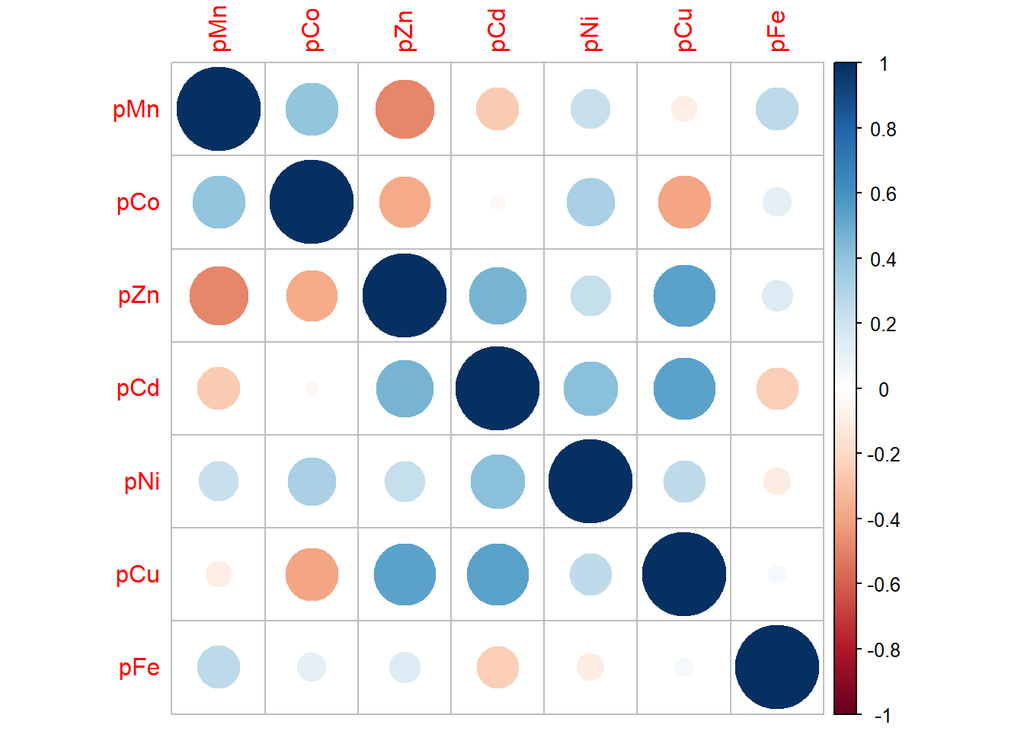

(#fig:corparticulate trace metals)Correlation matrix for Particulate trace metals

#### 3.2.7.2 CCA outputs

The CCA results are shown below:

Table 3.1: Table 3.1: Partitioning of scaled Chi-square for the CCA

| Partition | Inertia | Proportion |
| --- | --- | --- |
| Total | 0.262 | 1.000 |
| Constrained | 0.175 | 0.668 |
| Unconstrained | 0.087 | 0.332 |

Table 3.3: Table 3.3: The proportion of variation explained by each CCA axis for the CCA Particulate trace metals

|  | CCA1 | CCA2 | CCA3 | CCA4 | CCA5 | CCA6 | CCA7 | CA1 | CA2 | CA3 | CA4 | CA5 | CA6 | CA7 | CA8 |
| --- | --- | --- | --- | --- | --- | --- | --- | --- | --- | --- | --- | --- | --- | --- | --- |
| Eigenvalue | 0.125 | 0.033 | 0.013 | 0.004 | 0.001 | 0.000 | 0.000 | 0.055 | 0.022 | 0.005 | 0.003 | 0.002 | 0.001 | 0.000 | 0 |
| Proportion Explained | 0.477 | 0.125 | 0.048 | 0.016 | 0.003 | 0.001 | 0.000 | 0.209 | 0.082 | 0.020 | 0.012 | 0.006 | 0.002 | 0.001 | 0 |
| Cumulative Proportion | 0.477 | 0.601 | 0.649 | 0.665 | 0.667 | 0.668 | 0.668 | 0.877 | 0.959 | 0.978 | 0.990 | 0.996 | 0.999 | 1.000 | 1 |

Variance inflation factors were calculated using the `vif.cca` function. Variance inflation is an indicator of redundancy/colinearity of variables. Variance inflation factors greater than 10 generally indicate that the colinearity of the variables is likely to hinder interpretation of the CCA. The user guide states:

“Variance inflation is a diagnostic tool to identify useless constraints. A common rule is that values over 10 indicate redundant constraints. If later constraints are complete linear combinations of conditions or previous constraints, they will be completely removed from the estimation, and no biplot scores or centroids are calculated for these aliased constraint.”

Table 3.5: Table 3.5: Variance Inflation Factors for the CCA with Particulate trace metals

|  | x |
| --- | --- |
| pMn | 2.473 |
| pCo | 2.537 |
| pZn | 2.624 |
| pCd | 3.396 |
| pNi | 2.461 |
| pCu | 5.398 |
| pFe | 1.890 |

The results of the permutation test to test the significance of the CCA are shown below:

Table 3.15: Table 3.15: Significance of overall CCA for the CCA with Particulate trace metals

|  | Df | ChiSquare | F | Pr(>F) |
| --- | --- | --- | --- | --- |
| Model | 7 | 0.175 | 3.445 | 0.005 |
| Residual | 12 | 0.087 | NA | NA |

The significance of the CCA axes are shown below:

Table 3.17: Table 3.17: Significance of CCA axes for the CCA with Particulate trace metals

|  | Df | ChiSquare | F | Pr(>F) |
| --- | --- | --- | --- | --- |
| CCA1 | 1 | 0.125 | 17.213 | 0.005 |
| CCA2 | 1 | 0.033 | 4.499 | 0.575 |
| CCA3 | 1 | 0.013 | 1.728 | 0.991 |
| CCA4 | 1 | 0.004 | 0.563 | 1.000 |
| CCA5 | 1 | 0.001 | 0.095 | NA |
| CCA6 | 1 | 0.000 | 0.019 | NA |
| CCA7 | 1 | 0.000 | 0.001 | NA |
| Residual | 12 | 0.087 | NA | NA |

The significance of the terms for the environmental variables:

Table 3.19: Table 3.19: Significance of CCA terms (environmental variables) for the CCA with Particulate trace metals

|  | Df | ChiSquare | F | Pr(>F) |
| --- | --- | --- | --- | --- |
| pMn | 1 | 0.043 | 5.905 | 0.003 |
| pCo | 1 | 0.028 | 3.847 | 0.031 |
| pZn | 1 | 0.058 | 7.975 | 0.003 |
| pCd | 1 | 0.020 | 2.761 | 0.060 |
| pNi | 1 | 0.001 | 0.112 | 0.964 |
| pCu | 1 | 0.012 | 1.702 | 0.182 |
| pFe | 1 | 0.013 | 1.815 | 0.164 |
| Residual | 12 | 0.087 | NA | NA |

The CCA biplot is shown below:

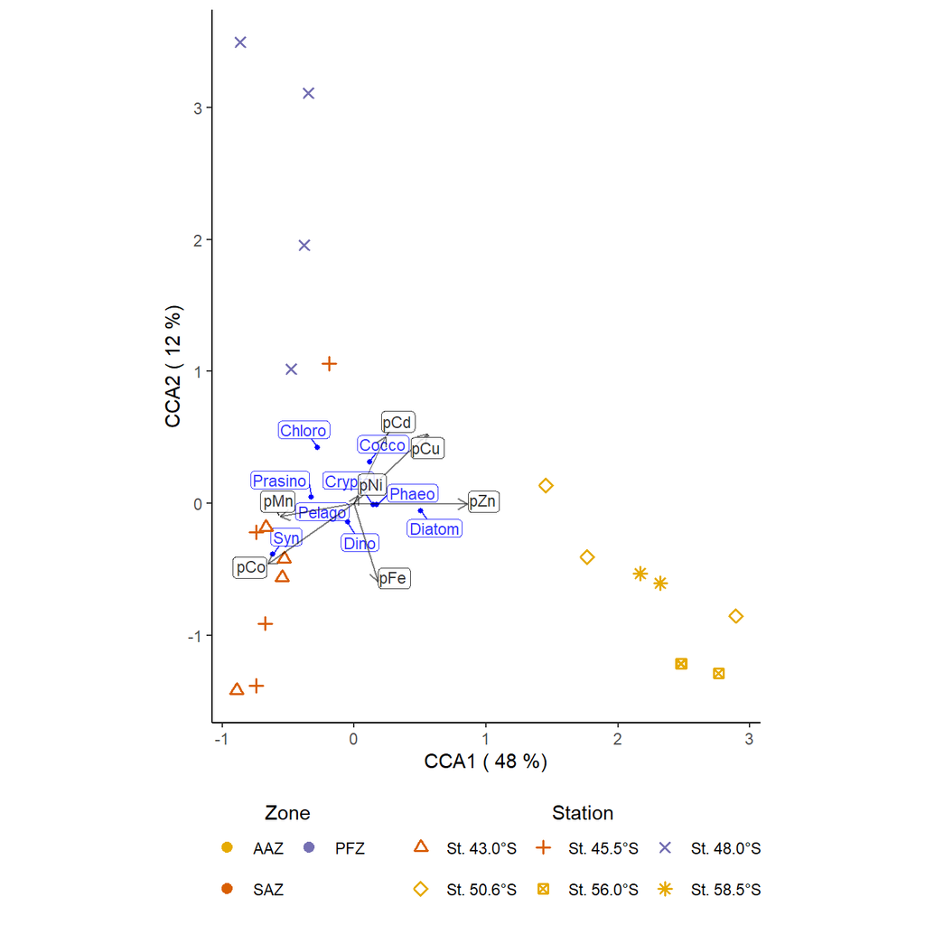

(#fig:particulate trace metals)Canonical correspondence analysis ordination diagram of absolute contributions of different phytoplankton groups for a CCA with Particulate trace metals. Arrows indicate environment variables: pMn, pCo, pZn, pCd, pNi, pCu, and pFe . Blue text refer to absolute contributions of phytoplankton groups. Stations are represented by shapes as per the legend and are colored according to the frontal zones in which they are located.

### 3.2.8 Analysis 7: Dissolved trace metals including the STZ station

#### 3.2.8.1 Correlation plots

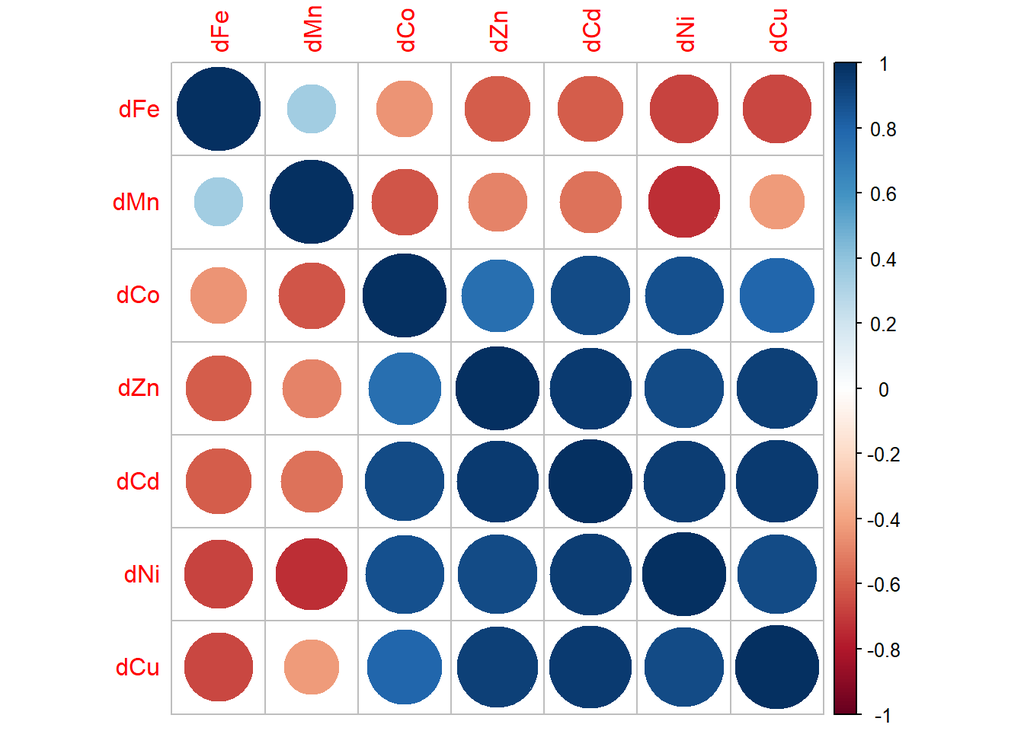

(#fig:cordissolved trace metalsstz)Correlation matrix for dissolved trace metals with STZ

#### 3.2.8.2 CCA outputs

The CCA results are shown below:

Table 3.1: Table 3.1: Partitioning of scaled Chi-square for the CCA

| Partition | Inertia | Proportion |
| --- | --- | --- |
| Total | 0.478 | 1.000 |
| Constrained | 0.428 | 0.895 |
| Unconstrained | 0.050 | 0.105 |

Table 3.3: Table 3.3: The proportion of variation explained by each CCA axis for the CCA dissolved trace metals with STZ

|  | CCA1 | CCA2 | CCA3 | CCA4 | CCA5 | CCA6 | CCA7 | CA1 | CA2 | CA3 | CA4 | CA5 | CA6 | CA7 | CA8 | CA9 |
| --- | --- | --- | --- | --- | --- | --- | --- | --- | --- | --- | --- | --- | --- | --- | --- | --- |
| Eigenvalue | 0.244 | 0.142 | 0.026 | 0.013 | 0.002 | 0.001 | 0.000 | 0.021 | 0.010 | 0.009 | 0.007 | 0.002 | 0.001 | 0.001 | 0.000 | 0 |
| Proportion Explained | 0.510 | 0.297 | 0.055 | 0.026 | 0.005 | 0.001 | 0.000 | 0.044 | 0.021 | 0.019 | 0.014 | 0.004 | 0.002 | 0.001 | 0.001 | 0 |
| Cumulative Proportion | 0.510 | 0.807 | 0.862 | 0.889 | 0.893 | 0.895 | 0.895 | 0.939 | 0.960 | 0.978 | 0.992 | 0.996 | 0.998 | 0.999 | 1.000 | 1 |

Variance inflation factors were calculated using the `vif.cca` function. Variance inflation is an indicator of redundancy/colinearity of variables. Variance inflation factors greater than 10 generally indicate that the colinearity of the variables is likely to hinder interpretation of the CCA. The user guide states:

“Variance inflation is a diagnostic tool to identify useless constraints. A common rule is that values over 10 indicate redundant constraints. If later constraints are complete linear combinations of conditions or previous constraints, they will be completely removed from the estimation, and no biplot scores or centroids are calculated for these aliased constraint.”

Table 3.5: Table 3.5: Variance Inflation Factors for the CCA with dissolved trace metals with STZ

|  | x |
| --- | --- |
| dFe | 2.508 |
| dMn | 8.791 |
| dCo | 14.432 |
| dZn | 20.304 |
| dCd | 100.570 |
| dNi | 50.122 |
| dCu | 38.516 |

The results of the permutation test to test the significance of the CCA are shown below:

Table 3.15: Table 3.15: Significance of overall CCA for the CCA with dissolved trace metals with STZ

|  | Df | ChiSquare | F | Pr(>F) |
| --- | --- | --- | --- | --- |
| Model | 7 | 0.428 | 23.03 | 0.001 |
| Residual | 19 | 0.050 | NA | NA |

The significance of the CCA axes are shown below:

Table 3.17: Table 3.17: Significance of CCA axes for the CCA with dissolved trace metals with STZ

|  | Df | ChiSquare | F | Pr(>F) |
| --- | --- | --- | --- | --- |
| CCA1 | 1 | 0.244 | 91.989 | 0.001 |
| CCA2 | 1 | 0.142 | 53.503 | 0.001 |
| CCA3 | 1 | 0.026 | 9.920 | 0.028 |
| CCA4 | 1 | 0.013 | 4.745 | 0.510 |
| CCA5 | 1 | 0.002 | 0.853 | 1.000 |
| CCA6 | 1 | 0.001 | 0.198 | NA |
| CCA7 | 1 | 0.000 | 0.004 | NA |
| Residual | 19 | 0.050 | NA | NA |

The significance of the terms for the environmental variables:

Table 3.19: Table 3.19: Significance of CCA terms (environmental variables) for the CCA with dissolved trace metals with STZ

|  | Df | ChiSquare | F | Pr(>F) |
| --- | --- | --- | --- | --- |
| dFe | 1 | 0.067 | 25.080 | 0.001 |
| dMn | 1 | 0.227 | 85.717 | 0.001 |
| dCo | 1 | 0.044 | 16.599 | 0.001 |
| dZn | 1 | 0.066 | 25.014 | 0.001 |
| dCd | 1 | 0.004 | 1.575 | 0.261 |
| dNi | 1 | 0.005 | 1.889 | 0.204 |
| dCu | 1 | 0.014 | 5.337 | 0.009 |
| Residual | 19 | 0.050 | NA | NA |

The CCA biplot is shown below:

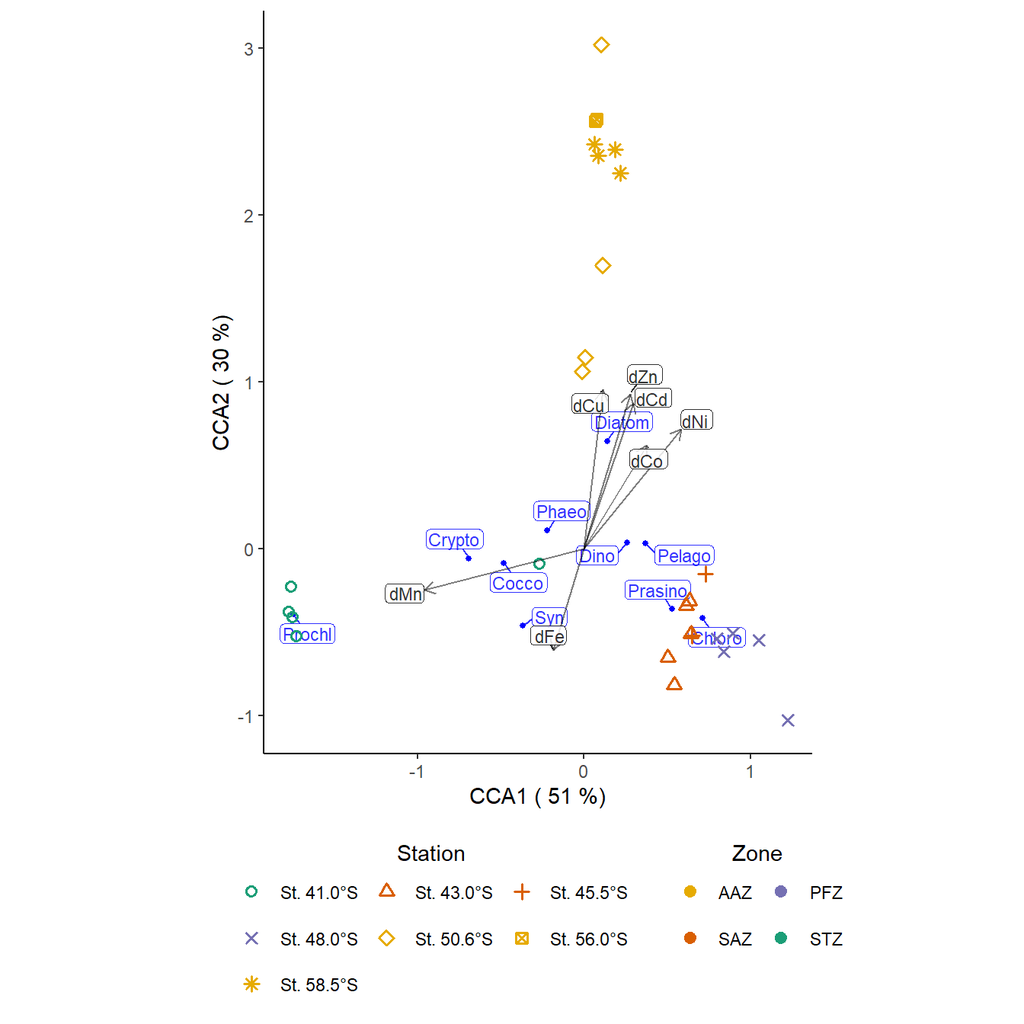

(#fig:dissolved trace metalsstz)Canonical correspondence analysis ordination diagram of absolute contributions of different phytoplankton groups for a CCA with dissolved trace metals with STZ. Arrows indicate environment variables: dFe, dMn, dCo, dZn, dCd, dNi, and dCu . Blue text refer to absolute contributions of phytoplankton groups. Stations are represented by shapes as per the legend and are colored according to the frontal zones in which they are located.

### 3.2.9 Analysis 8: Particulate trace metals with STZ

#### 3.2.9.1 Correlation plots

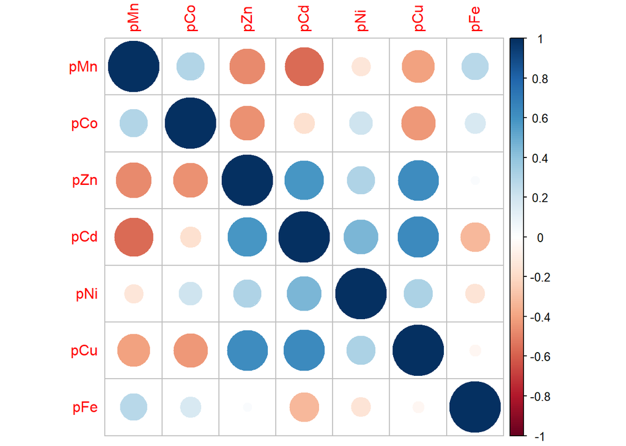

(#fig:corparticulate trace metalsstz)Correlation matrix for Particulate trace metals including the STZ station

#### 3.2.9.2 CCA outputs

The CCA results are shown below:

Table 3.1: Table 3.1: Partitioning of scaled Chi-square for the CCA

| Partition | Inertia | Proportion |
| --- | --- | --- |
| Total | 0.454 | 1.000 |
| Constrained | 0.295 | 0.651 |
| Unconstrained | 0.158 | 0.349 |

Table 3.3: Table 3.3: The proportion of variation explained by each CCA axis for the CCA Particulate trace metals including the STZ station

|  | CCA1 | CCA2 | CCA3 | CCA4 | CCA5 | CCA6 | CCA7 | CA1 | CA2 | CA3 | CA4 | CA5 | CA6 | CA7 | CA8 | CA9 |
| --- | --- | --- | --- | --- | --- | --- | --- | --- | --- | --- | --- | --- | --- | --- | --- | --- |
| Eigenvalue | 0.158 | 0.099 | 0.025 | 0.009 | 0.003 | 0.000 | 0.000 | 0.093 | 0.034 | 0.019 | 0.007 | 0.003 | 0.002 | 0.001 | 0 | 0 |
| Proportion Explained | 0.349 | 0.219 | 0.055 | 0.019 | 0.007 | 0.001 | 0.001 | 0.206 | 0.075 | 0.041 | 0.015 | 0.007 | 0.004 | 0.001 | 0 | 0 |
| Cumulative Proportion | 0.349 | 0.568 | 0.623 | 0.642 | 0.649 | 0.650 | 0.651 | 0.857 | 0.932 | 0.973 | 0.988 | 0.995 | 0.998 | 0.999 | 1 | 1 |

Variance inflation factors were calculated using the `vif.cca` function. Variance inflation is an indicator of redundancy/colinearity of variables. Variance inflation factors greater than 10 generally indicate that the colinearity of the variables is likely to hinder interpretation of the CCA. The user guide states:

“Variance inflation is a diagnostic tool to identify useless constraints. A common rule is that values over 10 indicate redundant constraints. If later constraints are complete linear combinations of conditions or previous constraints, they will be completely removed from the estimation, and no biplot scores or centroids are calculated for these aliased constraint.”

Table 3.5: Table 3.5: Variance Inflation Factors for the CCA with Particulate trace metals including the STZ station

|  | x |
| --- | --- |
| pMn | 1.952 |
| pCo | 2.504 |
| pZn | 2.891 |
| pCd | 4.165 |
| pNi | 2.125 |
| pCu | 5.527 |
| pFe | 1.562 |

The results of the permutation test to test the significance of the CCA are shown below:

Table 3.15: Table 3.15: Significance of overall CCA for the CCA with Particulate trace metals including the STZ station

|  | Df | ChiSquare | F | Pr(>F) |
| --- | --- | --- | --- | --- |
| Model | 7 | 0.295 | 3.991 | 0.001 |
| Residual | 15 | 0.158 | NA | NA |

The significance of the CCA axes are shown below:

Table 3.17: Table 3.17: Significance of CCA axes for the CCA with Particulate trace metals including the STZ station

|  | Df | ChiSquare | F | Pr(>F) |
| --- | --- | --- | --- | --- |
| CCA1 | 1 | 0.158 | 14.993 | 0.006 |
| CCA2 | 1 | 0.099 | 9.409 | 0.055 |
| CCA3 | 1 | 0.025 | 2.352 | 0.926 |
| CCA4 | 1 | 0.009 | 0.825 | 1.000 |
| CCA5 | 1 | 0.003 | 0.280 | NA |
| CCA6 | 1 | 0.000 | 0.043 | NA |
| CCA7 | 1 | 0.000 | 0.037 | NA |
| Residual | 15 | 0.158 | NA | NA |

The significance of the terms for the environmental variables:

Table 3.19: Table 3.19: Significance of CCA terms (environmental variables) for the CCA with Particulate trace metals including the STZ station

|  | Df | ChiSquare | F | Pr(>F) |
| --- | --- | --- | --- | --- |
| pMn | 1 | 0.150 | 14.159 | 0.001 |
| pCo | 1 | 0.045 | 4.250 | 0.028 |
| pZn | 1 | 0.054 | 5.157 | 0.014 |
| pCd | 1 | 0.019 | 1.779 | 0.214 |
| pNi | 1 | 0.007 | 0.663 | 0.659 |
| pCu | 1 | 0.012 | 1.127 | 0.376 |
| pFe | 1 | 0.008 | 0.804 | 0.534 |
| Residual | 15 | 0.158 | NA | NA |

The CCA biplot is shown below:

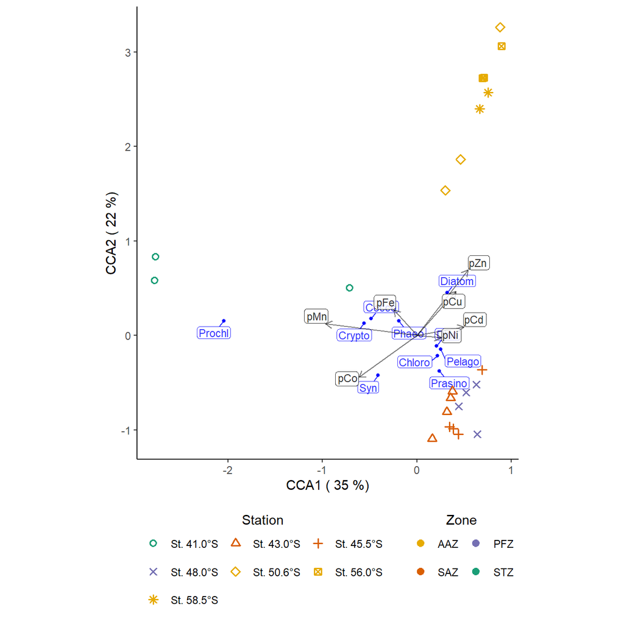

(#fig:particulate trace metalsstz)Canonical correspondence analysis ordination diagram of absolute contributions of different phytoplankton groups for a CCA with Particulate trace metals including the STZ station. Arrows indicate environment variables: pMn, pCo, pZn, pCd, pNi, pCu, and pFe . Blue text refer to absolute contributions of phytoplankton groups. Stations are represented by shapes as per the legend and are colored according to the frontal zones in which they are located.

### 3.2.10 Analysis 9a: Macro and dissolved trace metals with STZ

#### 3.2.10.1 Correlation plots

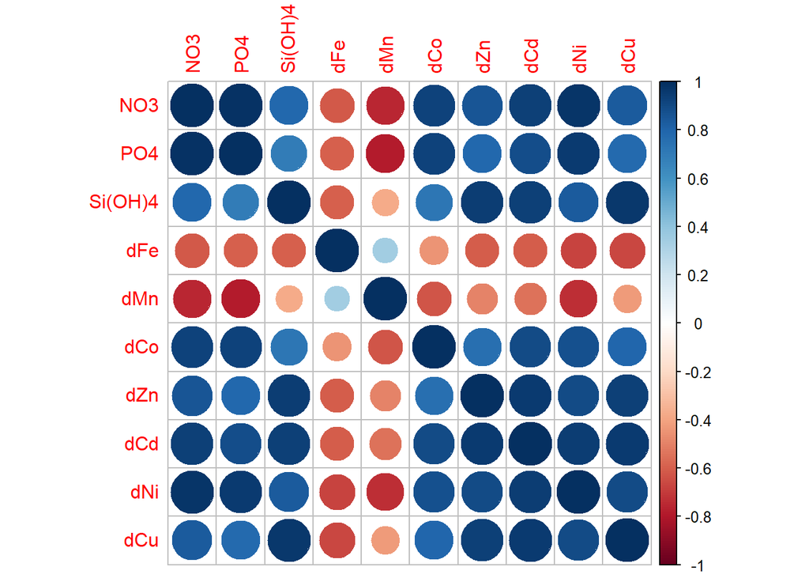

Figure 3.13: Correlation matrix for macronutrients and dissolved trace metals with STZ

#### 3.2.10.2 CCA outputs

The CCA results are shown below:

Table 3.1: Table 3.1: Partitioning of scaled Chi-square for the CCA

| Partition | Inertia | Proportion |
| --- | --- | --- |
| Total | 0.478 | 1.000 |
| Constrained | 0.438 | 0.915 |
| Unconstrained | 0.040 | 0.085 |

Table 3.3: Table 3.3: The proportion of variation explained by each CCA axis for the CCA macronutrients and dissolved trace metals with STZ

|  | CCA1 | CCA2 | CCA3 | CCA4 | CCA5 | CCA6 | CCA7 | CCA8 | CCA9 | CA1 | CA2 | CA3 | CA4 | CA5 | CA6 | CA7 | CA8 | CA9 |
| --- | --- | --- | --- | --- | --- | --- | --- | --- | --- | --- | --- | --- | --- | --- | --- | --- | --- | --- |
| Eigenvalue | 0.245 | 0.144 | 0.029 | 0.015 | 0.003 | 0.001 | 0.000 | 0.000 | 0.000 | 0.017 | 0.010 | 0.007 | 0.004 | 0.001 | 0.001 | 0.000 | 0.000 | 0 |
| Proportion Explained | 0.513 | 0.301 | 0.061 | 0.031 | 0.007 | 0.001 | 0.000 | 0.000 | 0.000 | 0.036 | 0.020 | 0.015 | 0.008 | 0.002 | 0.002 | 0.001 | 0.001 | 0 |
| Cumulative Proportion | 0.513 | 0.814 | 0.876 | 0.907 | 0.913 | 0.915 | 0.915 | 0.915 | 0.915 | 0.951 | 0.972 | 0.986 | 0.994 | 0.997 | 0.998 | 0.999 | 1.000 | 1 |

Variance inflation factors were calculated using the `vif.cca` function. Variance inflation is an indicator of redundancy/colinearity of variables. Variance inflation factors greater than 10 generally indicate that the colinearity of the variables is likely to hinder interpretation of the CCA. The user guide states:

“Variance inflation is a diagnostic tool to identify useless constraints. A common rule is that values over 10 indicate redundant constraints. If later constraints are complete linear combinations of conditions or previous constraints, they will be completely removed from the estimation, and no biplot scores or centroids are calculated for these aliased constraint.”

Table 3.5: Table 3.5: Variance Inflation Factors for the CCA with macronutrients and dissolved trace metals with STZ

|  | x |
| --- | --- |
| NO3 | 212.108 |
| PO4 | 160.738 |
| `Si(OH)4` | 63.021 |
| dFe | 2.945 |
| dMn | 17.340 |
| dCo | 33.351 |
| dZn | 22.910 |
| dCd | 169.938 |
| dNi | 113.822 |
| dCu | 93.610 |

The results of the permutation test to test the significance of the CCA are shown below:

Table 3.15: Table 3.15: Significance of overall CCA for the CCA with macronutrients and dissolved trace metals with STZ

|  | Df | ChiSquare | F | Pr(>F) |
| --- | --- | --- | --- | --- |
| Model | 10 | 0.438 | 17.288 | 0.001 |
| Residual | 16 | 0.040 | NA | NA |

The significance of the CCA axes are shown below:

Table 3.17: Table 3.17: Significance of CCA axes for the CCA with macronutrients and dissolved trace metals with STZ

|  | Df | ChiSquare | F | Pr(>F) |
| --- | --- | --- | --- | --- |
| CCA1 | 1 | 0.245 | 102.946 | 0.001 |
| CCA2 | 1 | 0.144 | 60.473 | 0.001 |
| CCA3 | 1 | 0.029 | 12.296 | 0.085 |
| CCA4 | 1 | 0.015 | 6.261 | 0.663 |
| CCA5 | 1 | 0.003 | 1.346 | 1.000 |
| CCA6 | 1 | 0.001 | 0.238 | NA |
| CCA7 | 1 | 0.000 | 0.099 | NA |
| CCA8 | 1 | 0.000 | 0.016 | NA |
| CCA9 | 1 | 0.000 | 0.009 | NA |
| Residual | 17 | 0.040 | NA | NA |

The significance of the terms for the environmental variables:

Table 3.19: Table 3.19: Significance of CCA terms (environmental variables) for the CCA with macronutrients and dissolved trace metals with STZ

|  | Df | ChiSquare | F | Pr(>F) |
| --- | --- | --- | --- | --- |
| NO3 | 1 | 0.156 | 61.737 | 0.001 |
| PO4 | 1 | 0.054 | 21.144 | 0.001 |
| `Si(OH)4` | 1 | 0.121 | 47.830 | 0.001 |
| dFe | 1 | 0.009 | 3.467 | 0.051 |
| dMn | 1 | 0.081 | 32.054 | 0.001 |
| dCo | 1 | 0.003 | 1.185 | 0.416 |
| dZn | 1 | 0.001 | 0.468 | 0.780 |
| dCd | 1 | 0.009 | 3.571 | 0.048 |
| dNi | 1 | 0.003 | 1.013 | 0.459 |
| dCu | 1 | 0.001 | 0.408 | 0.812 |
| Residual | 16 | 0.040 | NA | NA |

The CCA biplot is shown below:

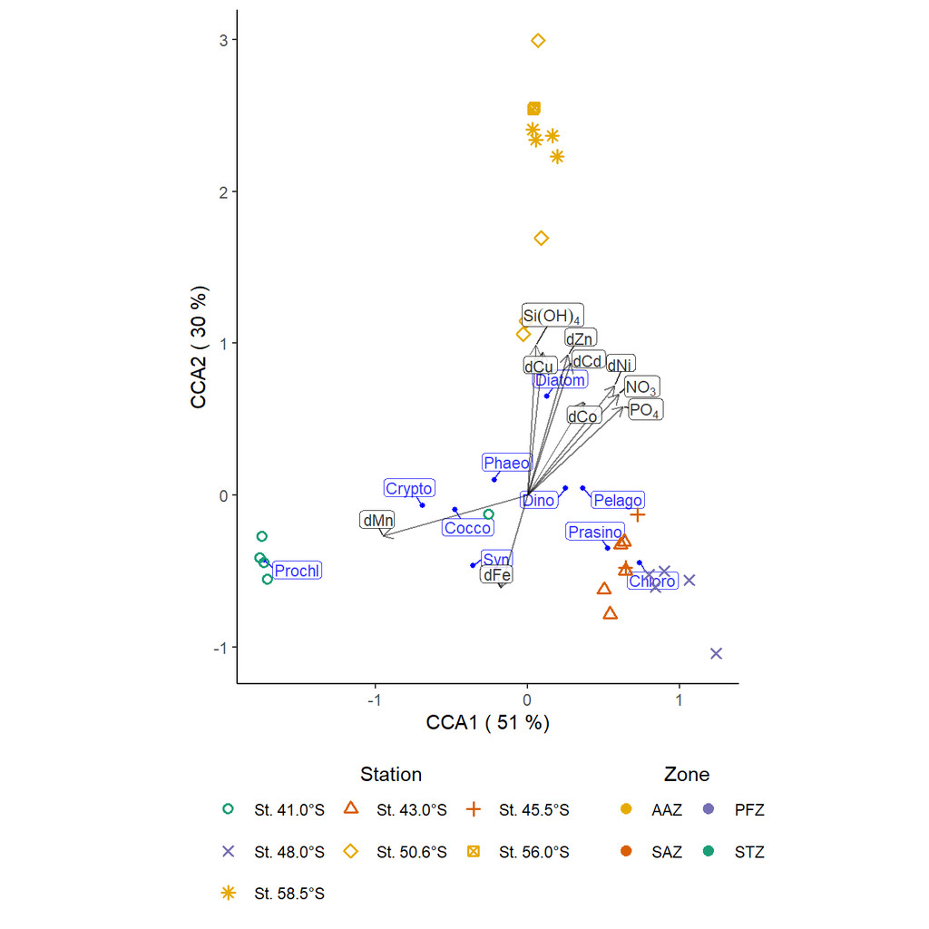

Figure 3.14: Canonical correspondence analysis ordination diagram of absolute contributions of different phytoplankton groups for a CCA with macronutrients and dissolved trace metals with STZ. Arrows indicate environment variables: NO3, PO4, Si(OH)4, dFe, dMn, dCo, dZn, dCd, dNi, and dCu . Blue text refer to absolute contributions of phytoplankton groups. Stations are represented by shapes as per the legend and are colored according to the frontal zones in which they are located.

### 3.2.11 Analysis 9b: Macro and dissolved trace metals without STZ

#### 3.2.11.1 Correlation plots

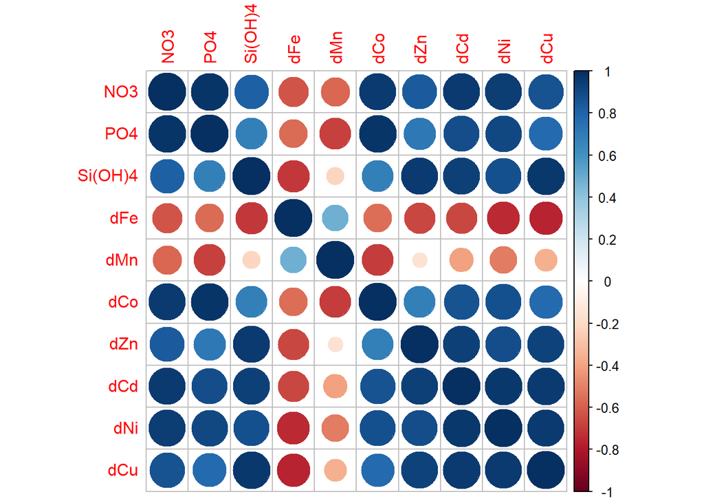

Figure 3.15: Correlation matrix for macronutrients and dissolved trace metals

#### 3.2.11.2 CCA outputs

The CCA results are shown below:

Table 3.1: Table 3.1: Partitioning of scaled Chi-square for the CCA

| Partition | Inertia | Proportion |
| --- | --- | --- |
| Total | 0.277 | 1.000 |
| Constrained | 0.245 | 0.886 |
| Unconstrained | 0.032 | 0.114 |

Table 3.3: Table 3.3: The proportion of variation explained by each CCA axis for the CCA macronutrients and dissolved trace metals

|  | CCA1 | CCA2 | CCA3 | CCA4 | CCA5 | CCA6 | CCA7 | CCA8 | CA1 | CA2 | CA3 | CA4 | CA5 | CA6 | CA7 | CA8 |
| --- | --- | --- | --- | --- | --- | --- | --- | --- | --- | --- | --- | --- | --- | --- | --- | --- |
| Eigenvalue | 0.176 | 0.045 | 0.019 | 0.004 | 0.001 | 0.001 | 0.000 | 0.000 | 0.019 | 0.008 | 0.002 | 0.001 | 0.001 | 0.000 | 0 | 0 |
| Proportion Explained | 0.637 | 0.161 | 0.067 | 0.015 | 0.004 | 0.002 | 0.001 | 0.000 | 0.069 | 0.029 | 0.007 | 0.004 | 0.004 | 0.001 | 0 | 0 |
| Cumulative Proportion | 0.637 | 0.798 | 0.865 | 0.879 | 0.883 | 0.885 | 0.886 | 0.886 | 0.955 | 0.984 | 0.991 | 0.995 | 0.999 | 0.999 | 1 | 1 |

Variance inflation factors were calculated using the `vif.cca` function. Variance inflation is an indicator of redundancy/colinearity of variables. Variance inflation factors greater than 10 generally indicate that the colinearity of the variables is likely to hinder interpretation of the CCA. The user guide states:

“Variance inflation is a diagnostic tool to identify useless constraints. A common rule is that values over 10 indicate redundant constraints. If later constraints are complete linear combinations of conditions or previous constraints, they will be completely removed from the estimation, and no biplot scores or centroids are calculated for these aliased constraint.”

Table 3.5: Table 3.5: Variance Inflation Factors for the CCA with macronutrients and dissolved trace metals

|  | x |
| --- | --- |
| NO3 | 113.821 |
| PO4 | 96.749 |
| `Si(OH)4` | 69.792 |
| dFe | 4.799 |
| dMn | 11.527 |
| dCo | 49.390 |
| dZn | 21.635 |
| dCd | 172.175 |
| dNi | 82.317 |
| dCu | 96.943 |

The results of the permutation test to test the significance of the CCA are shown below:

Table 3.15: Table 3.15: Significance of overall CCA for the CCA with macronutrients and dissolved trace metals

|  | Df | ChiSquare | F | Pr(>F) |
| --- | --- | --- | --- | --- |
| Model | 10 | 0.245 | 8.566 | 0.001 |
| Residual | 11 | 0.032 | NA | NA |

The significance of the CCA axes are shown below:

Table 3.17: Table 3.17: Significance of CCA axes for the CCA with macronutrients and dissolved trace metals

|  | Df | ChiSquare | F | Pr(>F) |
| --- | --- | --- | --- | --- |
| CCA1 | 1 | 0.176 | 72.741 | 0.001 |
| CCA2 | 1 | 0.045 | 18.382 | 0.046 |
| CCA3 | 1 | 0.019 | 7.663 | 0.750 |
| CCA4 | 1 | 0.004 | 1.675 | 1.000 |
| CCA5 | 1 | 0.001 | 0.416 | NA |
| CCA6 | 1 | 0.001 | 0.265 | NA |
| CCA7 | 1 | 0.000 | 0.063 | NA |
| CCA8 | 1 | 0.000 | 0.025 | NA |
| Residual | 13 | 0.032 | NA | NA |

The significance of the terms for the environmental variables:

Table 3.19: Table 3.19: Significance of CCA terms (environmental variables) for the CCA with macronutrients and dissolved trace metals

|  | Df | ChiSquare | F | Pr(>F) |
| --- | --- | --- | --- | --- |
| NO3 | 1 | 0.119 | 41.371 | 0.001 |
| PO4 | 1 | 0.053 | 18.455 | 0.001 |
| `Si(OH)4` | 1 | 0.048 | 16.723 | 0.001 |
| dFe | 1 | 0.008 | 2.854 | 0.065 |
| dMn | 1 | 0.003 | 1.100 | 0.373 |
| dCo | 1 | 0.001 | 0.287 | 0.818 |
| dZn | 1 | 0.001 | 0.509 | 0.690 |
| dCd | 1 | 0.010 | 3.416 | 0.056 |
| dNi | 1 | 0.001 | 0.500 | 0.669 |
| dCu | 1 | 0.001 | 0.443 | 0.718 |
| Residual | 11 | 0.032 | NA | NA |

The CCA biplot is shown below:

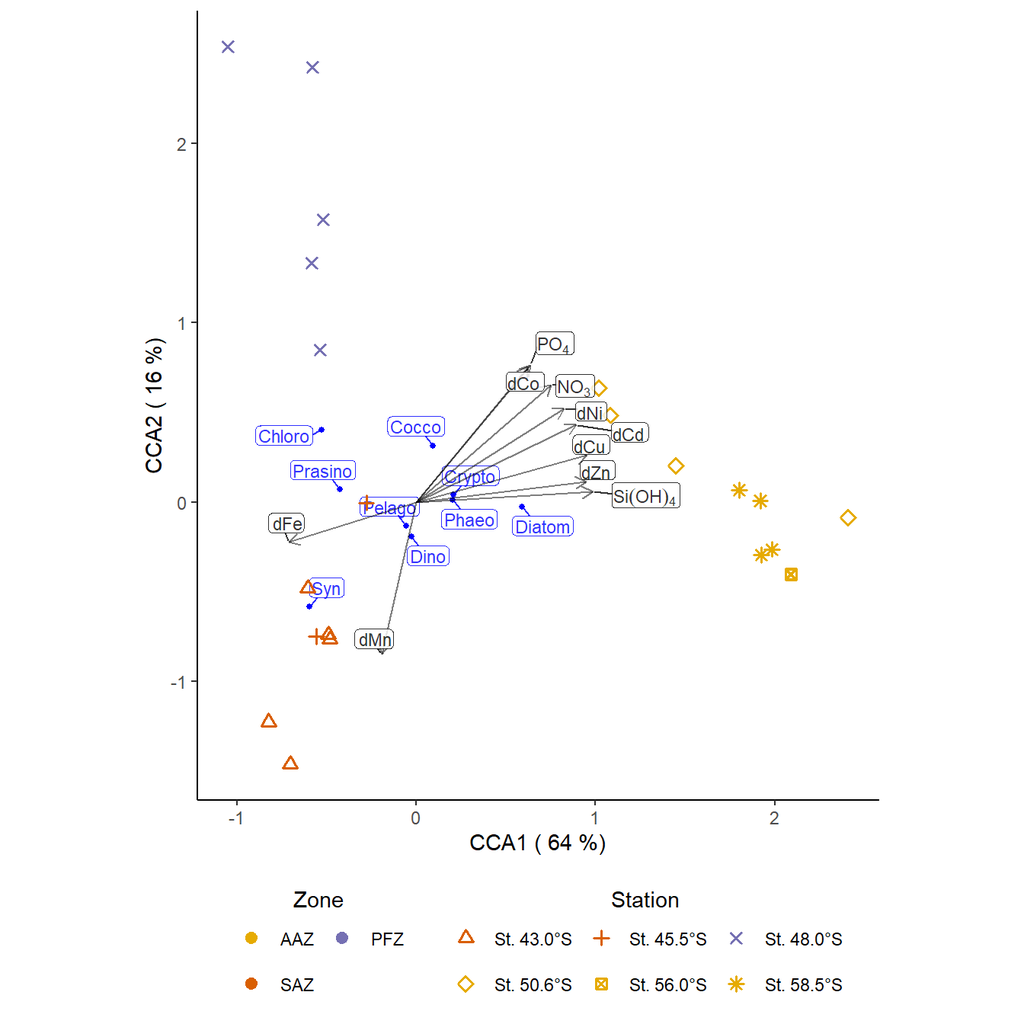

Figure 3.16: Canonical correspondence analysis ordination diagram of absolute contributions of different phytoplankton groups for a CCA with macronutrients and dissolved trace metals. Arrows indicate environment variables: NO3, PO4, Si(OH)4, dFe, dMn, dCo, dZn, dCd, dNi, and dCu . Blue text refer to absolute contributions of phytoplankton groups. Stations are represented by shapes as per the legend and are colored according to the frontal zones in which they are located.

## 3.3 Combined figure

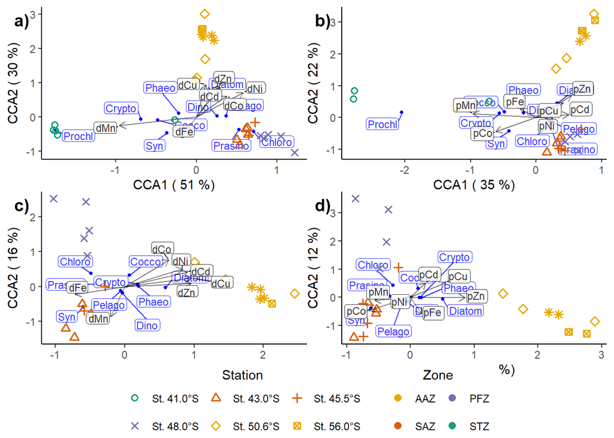

Figure 3.17: Combined CCA Biplots

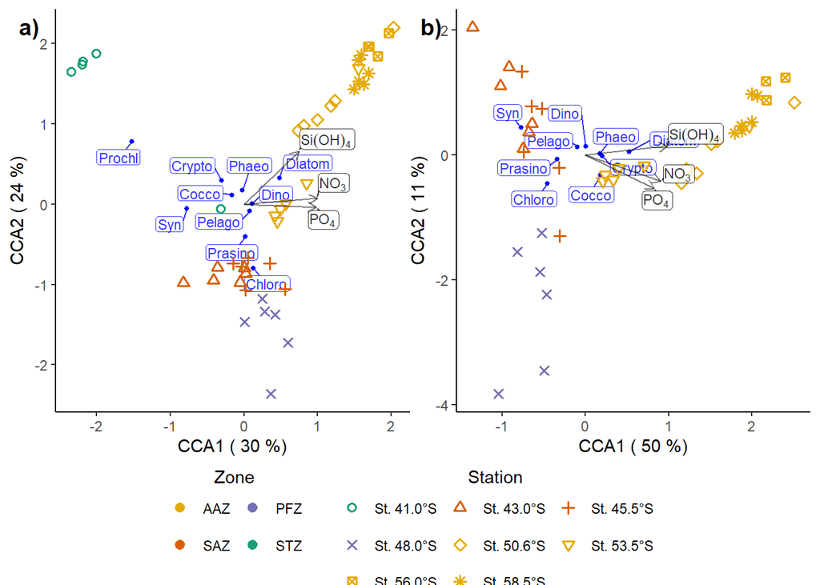

Figure 3.18: Combined CCA Biplots